# Regression with the Boston House Dataset

This notebook is a slightly adapted version from the notebook *Chapter 10 - Predicting Continuous Target Variables with Regression Analysis* from Sebastian Raschka's excellent book [Python Machine Learning](http://is.gd/ULX1Ee).

We additionally import the [Seaborn module](http://stanford.edu/~mwaskom/software/seaborn/index.html).

From its website: "Seaborn is a Python visualization library based on matplotlib. It provides a high-level interface for drawing attractive statistical graphics." Seaborn is especially useful to do some preliminary, visually, statistics oriented exploratory data analysis. It is often used in combination with the stats module. In this notebook,however, we will use it without stats.

```python
import numpy as np
import pandas as pd
import matplotlib.pyplot as plt
import seaborn as sns
%matplotlib inline
```

We will use the [housing dataset](http://archive.ics.uci.edu/ml/datasets/Housing) as our regression source. De dataset has the following features:

```
1. CRIM      per capita crime rate by town
2. ZN        proportion of residential land zoned for lots over
                 25,000 sq.ft.
3. INDUS     proportion of non-retail business acres per town
4. CHAS      Charles River dummy variable (= 1 if tract bounds
                 river; 0 otherwise)
5. NOX       nitric oxides concentration (parts per 10 million)
6. RM        average number of rooms per dwelling
7. AGE       proportion of owner-occupied units built prior to 1940
8. DIS       weighted distances to five Boston employment centres
9. RAD       index of accessibility to radial highways
10. TAX      full-value property-tax rate per $10,000
11. PTRATIO  pupil-teacher ratio by town
12. B        1000(Bk - 0.63)^2 where Bk is the proportion of blacks
                 by town
13. LSTAT    % lower status of the population
14. MEDV     Median value of owner-occupied homes in $1000's
```

```python
df = pd.read_csv('https://archive.ics.uci.edu/ml/machine-learning-databases/housing/housing.data', sep = '\s+', header=None)
df.columns = [
    'CRIM', 'ZN', 'INDUS', 'CHAS', 'NOX', 'RM', 'AGE', 'DIS', 'RAD', 'TAX', 'PTRATIO', 'B', 'LSTAT', 'MEDV']
df.head()
```

|  | CRIM | ZN | INDUS | CHAS | NOX | RM | AGE | DIS | RAD | TAX | PTRATIO | B | LSTAT | MEDV |
| --- | --- | --- | --- | --- | --- | --- | --- | --- | --- | --- | --- | --- | --- | --- |
| 0 | 0.00632 | 18.0 | 2.31 | 0 | 0.538 | 6.575 | 65.2 | 4.0900 | 1 | 296.0 | 15.3 | 396.90 | 4.98 | 24.0 |
| 1 | 0.02731 | 0.0 | 7.07 | 0 | 0.469 | 6.421 | 78.9 | 4.9671 | 2 | 242.0 | 17.8 | 396.90 | 9.14 | 21.6 |
| 2 | 0.02729 | 0.0 | 7.07 | 0 | 0.469 | 7.185 | 61.1 | 4.9671 | 2 | 242.0 | 17.8 | 392.83 | 4.03 | 34.7 |
| 3 | 0.03237 | 0.0 | 2.18 | 0 | 0.458 | 6.998 | 45.8 | 6.0622 | 3 | 222.0 | 18.7 | 394.63 | 2.94 | 33.4 |
| 4 | 0.06905 | 0.0 | 2.18 | 0 | 0.458 | 7.147 | 54.2 | 6.0622 | 3 | 222.0 | 18.7 | 396.90 | 5.33 | 36.2 |

MEDV is our target value. In contrast to the discrete, categorical targets, or class targets (values belonging to a restricted set of values) we saw before, MEDV is a continuous target variable. To predict its value we will use a regressor, rather than a classifier. In the [scatterplot matrix](http://stanford.edu/~mwaskom/software/seaborn/generated/seaborn.pairplot.html) below we plot some feature variables against our target variable. As we want to apply a linear regression model, we are looking for a linear relation between any feature variable and our target variable. Can you identify a candidate?

```python
df.shape
df.describe()
```

|  | CRIM | ZN | INDUS | CHAS | NOX | RM | AGE | DIS | RAD | TAX | PTRATIO | B | LSTAT | MEDV |
| --- | --- | --- | --- | --- | --- | --- | --- | --- | --- | --- | --- | --- | --- | --- |
| count | 506.000000 | 506.000000 | 506.000000 | 506.000000 | 506.000000 | 506.000000 | 506.000000 | 506.000000 | 506.000000 | 506.000000 | 506.000000 | 506.000000 | 506.000000 | 506.000000 |
| mean | 3.613524 | 11.363636 | 11.136779 | 0.069170 | 0.554695 | 6.284634 | 68.574901 | 3.795043 | 9.549407 | 408.237154 | 18.455534 | 356.674032 | 12.653063 | 22.532806 |
| std | 8.601545 | 23.322453 | 6.860353 | 0.253994 | 0.115878 | 0.702617 | 28.148861 | 2.105710 | 8.707259 | 168.537116 | 2.164946 | 91.294864 | 7.141062 | 9.197104 |
| min | 0.006320 | 0.000000 | 0.460000 | 0.000000 | 0.385000 | 3.561000 | 2.900000 | 1.129600 | 1.000000 | 187.000000 | 12.600000 | 0.320000 | 1.730000 | 5.000000 |
| 25% | 0.082045 | 0.000000 | 5.190000 | 0.000000 | 0.449000 | 5.885500 | 45.025000 | 2.100175 | 4.000000 | 279.000000 | 17.400000 | 375.377500 | 6.950000 | 17.025000 |
| 50% | 0.256510 | 0.000000 | 9.690000 | 0.000000 | 0.538000 | 6.208500 | 77.500000 | 3.207450 | 5.000000 | 330.000000 | 19.050000 | 391.440000 | 11.360000 | 21.200000 |
| 75% | 3.677083 | 12.500000 | 18.100000 | 0.000000 | 0.624000 | 6.623500 | 94.075000 | 5.188425 | 24.000000 | 666.000000 | 20.200000 | 396.225000 | 16.955000 | 25.000000 |
| max | 88.976200 | 100.000000 | 27.740000 | 1.000000 | 0.871000 | 8.780000 | 100.000000 | 12.126500 | 24.000000 | 711.000000 | 22.000000 | 396.900000 | 37.970000 | 50.000000 |

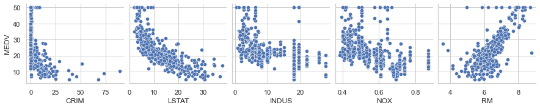

```python
sns.set(style='whitegrid', context='notebook')
sns.pairplot(df, x_vars=['CRIM', 'LSTAT', 'INDUS', 'NOX', 'RM'], y_vars=['MEDV'], height=2.5);
plt.show()
```

Another way to look at possible strong relationships between any feature variable and our target variable is to look at correlations. We wil use the [Pearson product-moment correlation](http://docs.scipy.org/doc/numpy/reference/generated/numpy.corrcoef.html) to analyse a possible correlation. Correlation is a value between -1 and 1. -1 for a strong negative relation, 0 for no relation at all and 1 for a strong positive relation. We will use a heatmap to visualize the correlation. There is a lot of noise in this heatmap. In fact, we are only interested in the first 5 cells of the last row as we are only interested in a correlation with our target variable.

Can you come up with a better visualization for correlation? Perhaps a plain bar chart?

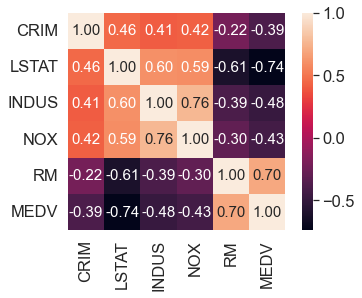

```python
cols = ['CRIM', 'LSTAT', 'INDUS', 'NOX', 'RM', 'MEDV']
cm = np.corrcoef(df[cols].values, rowvar=0)
sns.set(font_scale=1.5)
hm = sns.heatmap(cm,
    cbar=True,
    annot=True,
    square=True,
    fmt='.2f',
    annot_kws={'size': 15},
    yticklabels=cols,
    xticklabels=cols)
plt.show()
```

## Preprocessing

We see strong correlations between LSTAT and MEDV and RM and MEDV. As we saw in our scatter plot also a linear relation between RM and MEDV, RM is the feature we pick to base our linear regression model on.

```python
X = df[['RM']].values
# testing if using multiple features will change the model's effectiveness and how much
Xtest = df[['RM', 'LSTAT']].values
y = df['MEDV'].values
```

We are going to split the data into training and test data set

```python
from sklearn.model_selection import train_test_split
X_train, X_test, y_train, y_test = train_test_split(
     X, y, test_size=0.3, random_state=0
)
```

```python
Xtest_train, Xtest_test, ytest_train, ytest_test = train_test_split(
     Xtest, y, test_size=0.3, random_state=0
)
```

## Modeling

Now we are going to apply linear regression

```python
from sklearn.linear_model import LinearRegression

slr = LinearRegression()
slr.fit(X_train, y_train)
y_train_pred = slr.predict(X_train)
y_test_pred = slr.predict(X_test)

# set these values to showcase later
slopeSingleFeature = slr.coef_[0]
interceptSingleFeature = slr.intercept_

print('Slope: %.3f' % slr.coef_[0])
print('Intercept: %.3f' % slr.intercept_)
```

```
Slope: 9.311
Intercept: -35.994
```

```python
slrtest = LinearRegression()
slrtest.fit(Xtest_train, ytest_train)
ytest_train_pred = slrtest.predict(Xtest_train)
ytest_test_pred = slrtest.predict(Xtest_test)
# slope of the plane
print('Slope: %.3f' % slrtest.coef_[0])
# offset of slope on the y intercept
print('Intercept: %.3f' % slrtest.intercept_)
```

```
Slope: 5.274
Intercept: -2.537
```

Slope gets reduced by adding LSTAT

## Evaluation

Now let's look at the mean square error and r square. And how that line that we found ealier relates to our measures in the selected feature variable.

```python
from sklearn.metrics import mean_squared_error
print('MSE train: %.3f, test: %.3f' % (
    mean_squared_error(y_train, y_train_pred),
    mean_squared_error(y_test, y_test_pred)))
```

```
MSE train: 42.158, test: 47.033
```

```python
from sklearn.metrics import r2_score

# also keep these values for later
singleFeatureR2Train = r2_score(y_train, y_train_pred)
singleFeatureR2Test = r2_score(y_test, y_test_pred)

print('R^2 train: %.3f, test: %.3f' %
    (r2_score(y_train, y_train_pred),
    r2_score(y_test, y_test_pred)))
```

```
R^2 train: 0.503, test: 0.435
```

```python
print('R^2 train: %.3f, test: %.3f' %
    (r2_score(ytest_train, ytest_train_pred),
    r2_score(ytest_test, ytest_test_pred)))
```

```
R^2 train: 0.651, test: 0.607
```

The Results seem to be better for the two features than using only one

Let's plot the line.

```python
def lin_regplot(X, y, model):
    plt.scatter(X, y, c='blue')
    plt.plot(X, model.predict(X), color='red')
    return None
```

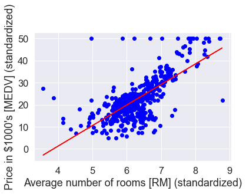

```python
lin_regplot(X, y, slr)
plt.xlabel('Average number of rooms [RM] (standardized)')
plt.ylabel('Price in $1000\'s [MEDV] (standardized)')
plt.show()
```

That doesn't look too odd. What we see is that there are quite a lot outliers: points that aren't really in the thick cloud. There are many statistical techniques to remove outliers from your measures. Instead of using such a technique, we will apply a linear regressor that is less susceptible for outliers: [RANdom SAmple Consensus (RANSAC)](http://scikit-learn.org/stable/modules/linear_model.html#ransac-regression)

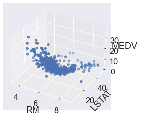

```python
# messing around with 3d plots
from mpl_toolkits.mplot3d import Axes3D

fig = plt.figure()
# 3d figure
ax = fig.add_subplot(111, projection = '3d')

# set axis
x = df['RM']
z = df['LSTAT']
y = df['MEDV']

ax.set_xlabel("RM")
ax.set_ylabel("LSTAT")
ax.set_zlabel("MEDV")

ax.scatter(x, y, z)

plt.show()
```

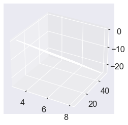

```python
fig = plt.figure()
# 3d figure
ax = fig.add_subplot(111, projection = '3d')
# print(range(int(df['RM'].min()), int(df['RM'].max())+1))
# print(range(10))
# set plane
xx, yy = np.meshgrid(
    range(int(df['RM'].min()), int(df['RM'].max())+1),
    range(int(df['MEDV'].min()), int(df['MEDV'].max())+1)
    )
z = (9 - xx - yy) / 2

# plot the plane
ax.plot_surface(xx, yy, z, alpha=0.5)

plt.show()

# This is currently not worth exploring further and my time is better used on the actual exercise
```

## Preprocessing

We use the same feature and the same train test split as before

## Modeling

We use the RANSAC modeling  
RANSAC model works by finding the line or plane that passes through the most amount of points effectively ignoring any possible deviating data

```python
from sklearn.linear_model import RANSACRegressor
ransac = RANSACRegressor(
    max_trials=1000000,
    min_samples=10,
    loss='absolute_loss',
    #residual_metric=lambda x: np.sum(np.abs(x), axis=1),
    residual_threshold=2.0,
    random_state=0)
ransac.fit(X_train, y_train)
y_train_pred = ransac.predict(X_train)
y_test_pred = ransac.predict(X_test)
```

Let's plot what Mr Ransac considered outliers and inliers.

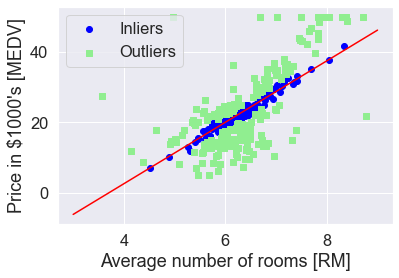

```python
# these masks are just large boolean arrays
inlier_mask = ransac.inlier_mask_
# print(inlier_mask)

# outliers = !inliers
outlier_mask = np.logical_not(inlier_mask)

# creates array of points from 3 to 10 with spaces of 1
line_X = np.arange(3, 10, 1)
# print(line_X)
# print(line_X.shape)

# reforms the array to make every value an array inside of the array
line_X_2d = line_X.reshape(-1,1)
# print(line_X_2d)
# print(line_X_2d.shape)

# creates another array for the y points for the given x coordinates
line_y_ransac = ransac.predict(line_X_2d)
# print(line_y_ransac)

# Plot
plt.scatter(X_train[inlier_mask], y_train[inlier_mask], c='blue', marker='o', label='Inliers')
plt.scatter(X_train[outlier_mask], y_train[outlier_mask], c='lightgreen', marker='s', label='Outliers')
plt.plot(line_X, line_y_ransac, color='red')
plt.xlabel('Average number of rooms [RM]')
plt.ylabel('Price in $1000\'s [MEDV]')
plt.legend(loc='upper left')
plt.show()
```

Has this lead to a different slope and intercept? - It has!

```python
print('Slope: %.3f' % ransac.estimator_.coef_[0])
print('Intercept: %.3f' % ransac.estimator_.intercept_)
```

```
Slope: 8.722
Intercept: -32.293
```

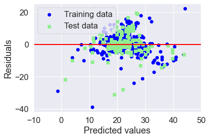

```python
# print([len(y_train_pred), len(y_train)])
plt.scatter(y_train_pred, y_train_pred - y_train,
    c='blue', marker='o', label='Training data'
)
plt.scatter(y_test_pred,  y_test_pred - y_test,
    c='lightgreen', marker='s', label='Test data'
)
plt.xlabel('Predicted values')
# Residuals means how far off the model was from predicting the correct value
plt.ylabel('Residuals')
plt.legend(loc='upper left')
plt.hlines(y=0, xmin=-10, xmax=50, lw=2, color='red')
plt.xlim([-10, 50])
plt.show()
```

```python
from sklearn.metrics import mean_squared_error
print('MSE train: %.3f, test: %.3f' % (
    mean_squared_error(y_train, y_train_pred),
    mean_squared_error(y_test, y_test_pred)))
```

```
MSE train: 42.329, test: 46.800
```

```python
from sklearn.metrics import r2_score
print('R^2 train: %.3f, test: %.3f' %
    (r2_score(y_train, y_train_pred),
    r2_score(y_test, y_test_pred)))
```

```
R^2 train: 0.501, test: 0.438
```

Surprisingly almost identical results to linear regression

## Now it is your turn.

### Since LSTAT has also strong correlation with MEDV. Now let's select two features and perform the linear regression. Compare the evaluation with before. Which model is better according to you, and why? Compare your reasoning with another student.

Was actually doing this while messing around in the previous part already.  
During this I made the observation that using multiple features indeed changed the intersect and slope of the line,  
this also increased the accuracy metrics

```python
# Create the arrays for the features and target
X = df[['RM', 'LSTAT']].values
y = df['MEDV'].values
print(df[['RM', 'LSTAT']].head())
```

```
      RM  LSTAT
0  6.575   4.98
1  6.421   9.14
2  7.185   4.03
3  6.998   2.94
4  7.147   5.33
```

```python
# Split data into testing and training
X_train, X_test, y_train, y_test = train_test_split(
     X, y, test_size=0.3, random_state=0
)
```

```python
# setting up linear regression model using sklearn's algorithm
slr = LinearRegression()
# train the model
slr.fit(X_train, y_train)
# get predictions of train and test data
y_train_pred = slr.predict(X_train)
y_test_pred = slr.predict(X_test)
# slope of the plane
print('New Slope: %.3f' % slr.coef_[0])
# offset of slope on the y intercept
print('New Intercept: %.3f' % slr.intercept_)

# set these values to showcase later
slopeRANSAC = slr.coef_[0]
interceptRANSAC = slr.intercept_

print('\nSF Slope: %.3f' % slopeSingleFeature)
print('SF Intercept: %.3f' % interceptSingleFeature)
```

```
New Slope: 5.274
New Intercept: -2.537

SF Slope: 9.311
SF Intercept: -35.994
```

```python
# also keep these values for later
RANSACR2Train = r2_score(y_train, y_train_pred)
RANSACR2Test = r2_score(y_test, y_test_pred)

# get and show the R2 score
print('New R^2 train: %.3f, New test: %.3f' %
    (RANSACR2Train,
    RANSACR2Test))

print('SF R^2 train: %.3f, SF test: %.3f' %
    (singleFeatureR2Train,
    singleFeatureR2Test))
```

```
New R^2 train: 0.651, New test: 0.607
SF R^2 train: 0.503, SF test: 0.435
```

As you can see the new model with applying two features gives a more accurate prediction

### Instead of RANSAC, can you manually find out the outlier and remove the outlier? Compare the prediction result

```
New Slope: 9.311
New Intercept: -35.994

SF Slope: 9.311
SF Intercept: -35.994
```

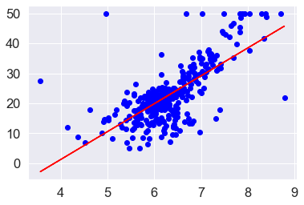

```python
X_train, X_test, y_train, y_test = train_test_split(
     df[['RM']].values, df['MEDV'].values, test_size=0.3, random_state=0
)
plt.scatter(X_train, y_train, c='blue')

# Generate slope and offset using polyfit
a, b = np.polyfit(X_train.flatten(), y_train.flatten(), 1)
plt.plot(x, a*x + b, c='red')

print('New Slope: %.3f' % a)
print('New Intercept: %.3f' % b)

print('\nSF Slope: %.3f' % slopeSingleFeature)
print('SF Intercept: %.3f' % interceptSingleFeature)
```

As you can see is this line identical to the line generated using sklearn's system meaning that they probably used a very similar implementation of numpy's polyfit.

[figure not shown]

```python
from numpy import linalg as LA

# def Test(test):
#     print(test)
# Test('Hello World!')

# Wish.com Ransac method of checking if a point is within a set area around a line
def RansacMask(slope, yoffset, points, lineRange = 0.2):
# y = ax + b
# y = slope * x + offset
    lineP1 = np.array([0, slope*0+yoffset])
    lineP2 = np.array([10, slope*10+yoffset])

    inliers = []
    for point in points:
        inliers.append(LA.norm(np.cross(lineP2-lineP1, lineP1-point))/LA.norm(lineP2-lineP1) < lineRange)
    return inliers

points = []
for i in range(len(X_train)):
    points.append(np.append(X_train[i], y_train[i]))

# print(points)
# print([len(X_train), len(RansacMask(a, b, points))])
# print(Ransac(np.array([0,0]), [2,2], [1,2], 0.2))
# print(RansacMask(a, b, points))

# I advise you to try and changing the line range and seeing that the amount captured changes,
# this showcases how to find and remove possible outliers without having to do it in a time consuming manual way
inliers = RansacMask(a, b, points)
outliers = np.logical_not(inliers)

plt.scatter(X_train[inliers], y_train[inliers], c='blue', marker='o', label='Inliers')
plt.scatter(X_train[outliers], y_train[outliers], c='lightgreen', marker='s', label='Outliers')
plt.plot(line_X, line_y_ransac, color='red')
plt.xlabel('Average number of rooms [RM]')
plt.ylabel('Price in $1000\'s [MEDV]')
plt.legend(loc='upper left')
plt.show()
# My own Wish.com method of doing ransac I guess
```

Here I created my own way of finding all points close to the line generated with polyfit.  
I have structured my logic so that it returns an array of booleans just like ransac's masks,  
this makes it very easy to remove any outliers in the future

### Or look for another algorithm such as Ridge or SDGClassifier to remove the outlier

```python
from sklearn.linear_model import Ridge
X = df[['RM', 'LSTAT']].values
y = df['MEDV'].values

X_train, X_test, y_train, y_test = train_test_split(
     X, y, test_size=0.3, random_state=0
)

clf = Ridge()
clf.fit(X_train, y_train)
y_train_pred = clf.predict(X_train)
y_test_pred = clf.predict(X_test)

print('New Slope: %.3f' % clf.coef_[0])
print('New Intercept: %.3f' % clf.intercept_)

print('\nRANSAC Slope: %.3f' % slopeRANSAC)
print('RANSAC Intercept: %.3f' % interceptRANSAC)


print('\nNew R^2 train: %.6f, New test: %.6f' %
    (r2_score(y_train, y_train_pred),
    r2_score(y_test, y_test_pred)))

print('RANSAC R^2 train: %.6f, RANSAC test: %.6f' %
    (RANSACR2Train,
    RANSACR2Test))
```

```
New Slope: 5.225
New Intercept: -2.192

RANSAC Slope: 5.274
RANSAC Intercept: -2.537

New R^2 train: 0.650936, New test: 0.607185
RANSAC R^2 train: 0.650944, RANSAC test: 0.606979
```